**Logistic Regression**

```r
library(ggplot2)
library(GGally)
library(dplyr)
task<-read.table("C:/Users/Missao/Documents/GitHub/IODS-project/alc.csv", header=TRUE, sep=";")
names(task)
```

```
##  [1] "school"     "sex"        "age"        "address"    "famsize"
##  [6] "Pstatus"    "Medu"       "Fedu"       "Mjob"       "Fjob"
## [11] "reason"     "nursery"    "internet"   "guardian"   "traveltime"
## [16] "studytime"  "failures"   "schoolsup"  "famsup"     "paid"
## [21] "activities" "higher"     "romantic"   "famrel"     "freetime"
## [26] "goout"      "Dalc"       "Walc"       "health"     "absences"
## [31] "G1"         "G2"         "G3"         "alc_use"    "high_use"
```

The dataset contains data on student alcohol consumption based on the dataset from https://archive.ics.uci.edu/ml/datasets/Student+Performance. The variables not used for joining the two data have been combined by averaging (including the grade variables). ‘alc_use’ is the average of ‘Dalc’ and ‘Walc’ - (workday alcohol consumption and weekend alcohol consumption). ‘high_use’ is TRUE if ‘alc_use’ is higher than 2 and FALSE otherwise.

*Hypotheses*

According to the DataCamp exercises, we can assume that sex (males), failures and absences (those who have them), are positively correlated with alcohol consumption. As a student, I can also state that people who like to party are usually have high level of alcohol consumption, and that would be my fourth hypothesis.

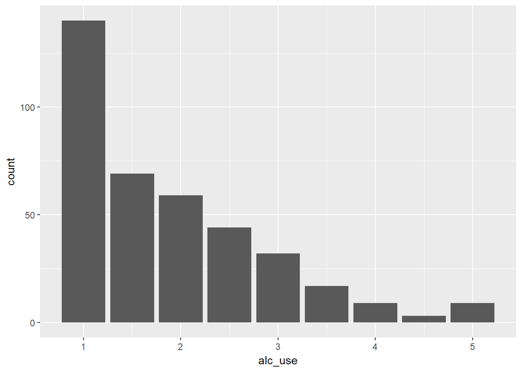

```r
par(mfrow=c(1,2))
ggplot(data = task, aes(x = alc_use)) + geom_bar()
```

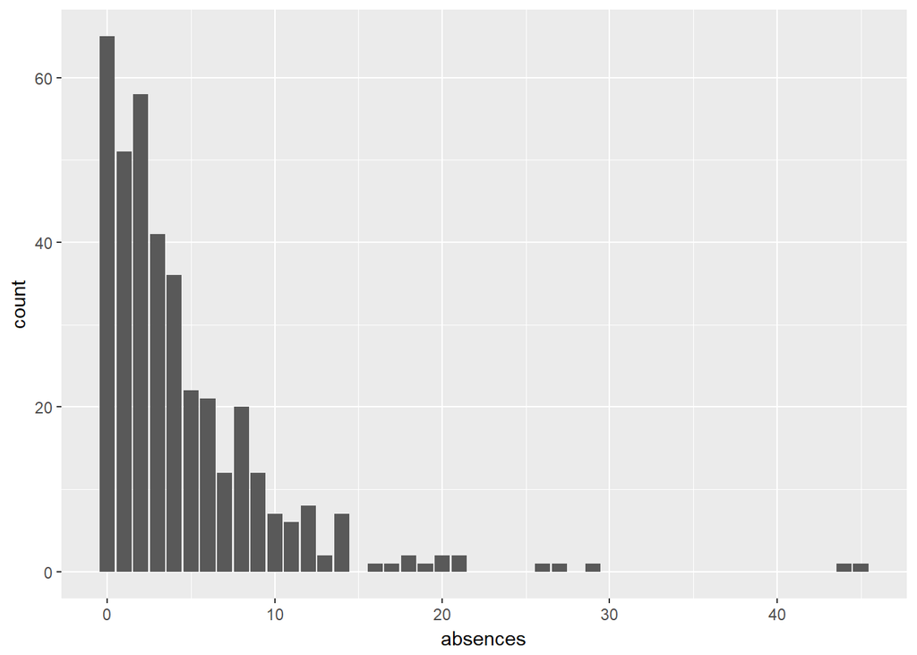

```r
ggplot(data = task, aes(x = absences)) + geom_bar()
```

```r
task %>% group_by(alc_use, sex) %>% summarise(count = n(), mean_failures = mean(failures), mean_absences = mean(absences), mean_goout = mean(goout))
```

```
## # A tibble: 17 x 6
## # Groups:   alc_use [?]
##    alc_use    sex count mean_failures mean_absences mean_goout
##      <dbl> <fctr> <int>         <dbl>         <dbl>      <dbl>
##  1     1.0      F    87    0.10344828      3.781609   2.896552
##  2     1.0      M    53    0.11320755      2.660377   2.509434
##  3     1.5      F    42    0.04761905      4.642857   2.857143
##  4     1.5      M    27    0.29629630      3.592593   2.888889
##  5     2.0      F    27    0.25925926      5.000000   3.296296
##  6     2.0      M    32    0.18750000      3.000000   2.906250
##  7     2.5      F    26    0.19230769      6.576923   2.961538
##  8     2.5      M    18    0.05555556      6.222222   3.777778
##  9     3.0      F    11    0.54545455      7.636364   4.090909
## 10     3.0      M    21    0.57142857      5.285714   3.952381
## 11     3.5      F     3    0.33333333      8.000000   3.333333
## 12     3.5      M    14    0.50000000      5.142857   3.857143
## 13     4.0      F     1    0.00000000      3.000000   4.000000
## 14     4.0      M     8    0.25000000      6.375000   4.250000
## 15     4.5      M     3    0.00000000     12.000000   3.666667
## 16     5.0      F     1    0.00000000      3.000000   5.000000
## 17     5.0      M     8    0.62500000      7.375000   4.125000
```

The result of cross-tabulation proves that there can be seen a trend with positive correlation, and our hypotheses are proven to some extent.

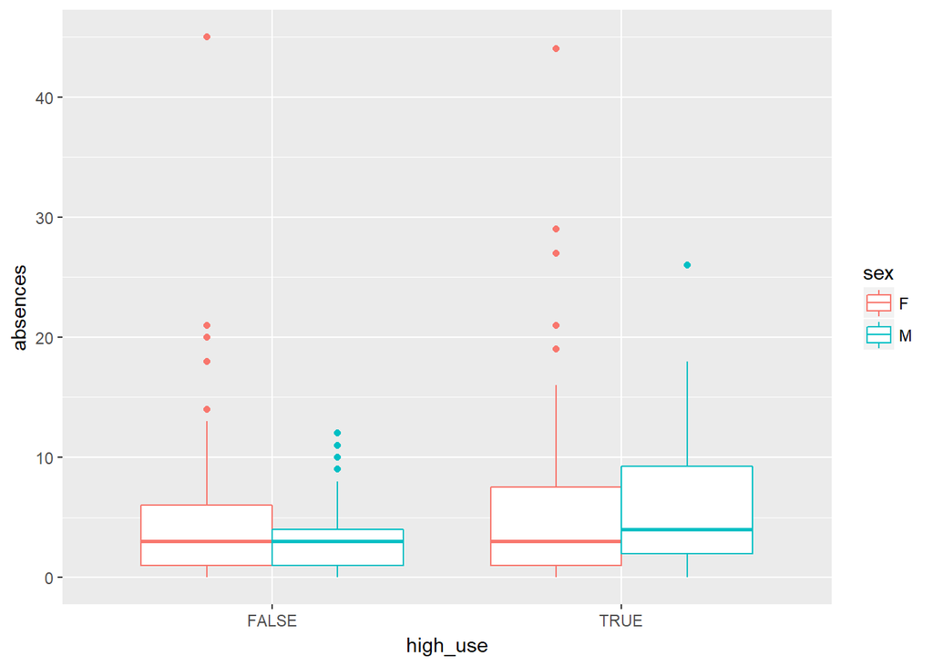

```r
par(mfrow=c(1,2))
g1 <- ggplot(task, aes(x = high_use, col = sex, y = absences))
g1 + geom_boxplot() + ylab("absences")
```